# Aula 5 - Econometria de Séries Temporais

João Ricardo F. de Lima

15 de março de 2022.

# 1 Raiz Unitária

Considere um processo AR(1)

$$Y_t=\phi_1Y_{t-1}+\epsilon_t
\tag{1}$$

se $\phi_1=1$, tem-se que
$$Y_t=Y_{t-1}+\epsilon_t
\tag{2}$$

ou seja, $Y_t$ é um passeio aleatório, não estacionário, possui uma raiz unitária. Contudo, a existência da raiz unitária não é devido o fato de $\phi_1=1$ no modelo (1) acima. Está relacionado com as raízes de um polinômio;

Usando o operador de defasagem na equação (1), tem-se

$$Y_t=\phi_1LY_t+\epsilon_t
\tag{3}$$

rearranjando os termos

$$Y_t-\phi_1LY_t=\epsilon_t
\tag{4}$$

$$(1-\phi_1L)Y_t=\epsilon_t
\tag{5}$$

em que $1-\phi_1L=0$ é denominada de equação característica/polinômio 1 grau.

Resolvendo para L,
$$\phi_1L=1
\tag{6}$$

$$L=\frac{1}{\phi_1}
\tag{7}$$

denominada de raiz da equação. Identificar se existe raiz unitária no AR(1) é saber se L=1. No AR(1), L=1 quando $\phi_1=1$. Se $\phi_1=1$, L=1 e o processo possui raiz unitária;

Se $|\phi_1|<1$, $|L|>1$, a raiz está fora do círculo unitário, não possui raiz unitária, a série é estacionária;

Se $|\phi_1|>1$, $|L|<1$, a série é dita explosiva, não estacionária, sem interesse para análise.

## 1.1 Conceito de Integração

Uma série não estacionária possui comportamento de passeio aleatório, que é representado pela presença de raízes unitárias na equação característica da série. Esta, para se tornar estacionária, precisa ser diferenciada tantas vezes quanto for o número de raízes unitárias. Assim, tem-se o conceito de *séries integradas*;

Uma série é integrada de ordem d, designada por $Y_t \sim I(d)$, se for necessário diferenciá-la d vezes para torná-la estacionária;

## 1.2 Propriedades de Séries Integradas

Considere três séries $X_t, Y_t$ e $Z_t$. Tem-se as seguintes propriedades de séries integradas:

1. Se $X_t \sim I(0)$ e $Y_t \sim I(1)$, então $Z_t=X_t+Y_t \sim I(1)$, isto é, uma combinação linear de séries estacionárias e não estacionárias é não estacionária;
2. Se $X_t \sim I(d)$, então $Z_t=a+bX_t \sim I(d)$, onde a e b são constantes. Em outras palavras, uma combinação linear de uma série I(d) também é uma série I(d);
3. Se $X_t \sim I(d_1)$ e $Y_t \sim I(d_2)$ com $d_1 < d_2$, então, $Z_t=aX_t+bY_t \sim I(d_2)$
4. Se $X_t \sim I(d)$ e $Y_t \sim I(d)$, então, $Z_t=aX_t+bY_t \sim I(d^*)$; $d^*$ em geral é igual a d, mas em alguns casos $d^* \leq d$.

## 1.3 Determinação da Estacionariedade

Para identificar se uma série possui raiz unitária, deve-se realizar testes específicos desenvolvidos com esta finalidade. Existem diversos: DF (Dickey-Fuller), ADF (Dickey-Fuller aumentado), DF-GLS (Dickey-Fuller por minimos quadrados generalizados); Phillips-Perron, KPSS, etc.

Apresentamos aqui apenas o DF, ADF e o DF-GLS, que são os mais usados. No DF, considere um processo autorregressivo de ordem p, dado por:

$$y_t=\rho y_{t-1}+\epsilon_t$$
em que $\epsilon_t$ é um termo ruído branco, ou seja, possui média zero e variância constante. O que se deseja testar é se $\rho=1$, ou seja, y possui raiz unitária, sendo não estacionário. Perceba que com $\rho=1$ o processo AR acima se torna um passeio aleatório sem constante e todo PA é por definição não estacionário. Por conveniência estatística o teste é conduzido com a equação em primeira diferença.

$$y_t-y_{t-1}=\rho y_{t-1}-y_{t-1}+\epsilon_t$$
$$\Delta y_t=(\rho-1)y_{t-1}+\epsilon_t$$

$$\Delta y_t=\delta y_{t-1}+\epsilon_t$$

em que $\delta=\rho-1$. Se $\rho=1$, $\delta=0$. Desta forma, $\Delta y$ seria igual a um ruído branco, estacionário.

Assim, a hipótese nula do teste é que $\delta=0$, ou seja, $\rho=1$ e a série possui raiz unitária, sendo estacionária na primeira diferença;

A significância de $\delta$ segue uma distribuição tabulada por Dickey e Fuller denominada de $\tau$.

No teste, é possível definir na equação de teste se a mesma possui intercepto e tendência. No ADF, considere um processo autorregressivo de ordem p, dado por:

$$\Delta y_t=\delta y_{t-1}+ \sum_{j=1}^{p-1} \rho_{j+1} \Delta
y_{t-j}+\epsilon_t$$

A diferença entre o DF e o ADF está na inclusão de termos de diferença defasados ($\Delta y_{t-j}$).

O objetivo de incluir estes termos de diferença defasados é tornar os erros serialmente independentes, dado que a existência de autocorrelação nos resíduos invalida os valores da distribuição $\tau$.

No mais, a estatística deste teste é a mesma do DF, sendo usado os valores críticos de $\tau$.

A hipótese nula deste teste é a mesma do DF, ou seja, a série possui raiz unitária, sendo não estacionaria.

O teste ADF também pode incluir termos determinísticos de intercepto e tendência. Como o mesmo possui termos de diferença defasados, tem-se o problema de determinar o numero de defasagens p.

Para isto, deve-se usar os critérios de informação de Akaike ou Schwarz disponíveis nos softwares.

# 2 Demonstração no R

## 2.1 Entrada dos dados

```r
#Direcionado o R para o Diretorio a ser trabalhado
setwd('C:/Users/Joao Ricardo Lima/Dropbox/tempecon/facape/econometria2')

#Pacotes utilizados
library(forecast)
library(ggplot2)
library(urca)
library(tseries)

# Entrada de dados e configuração como série temporal
ipca <- read.csv2('econ2Raula3arq1.csv', header=T, sep=";", dec=",")
ipca <- ipca[,-1]
ipca <- ts(ipca, start=c(1999,08), freq = 12)

selic <- read.csv2('econ2Raula3arq2.csv', header=T, sep=';', dec=',')
selic <- selic[,-1]
selic <- ts(selic, start=c(1999, 08), freq=12)
```

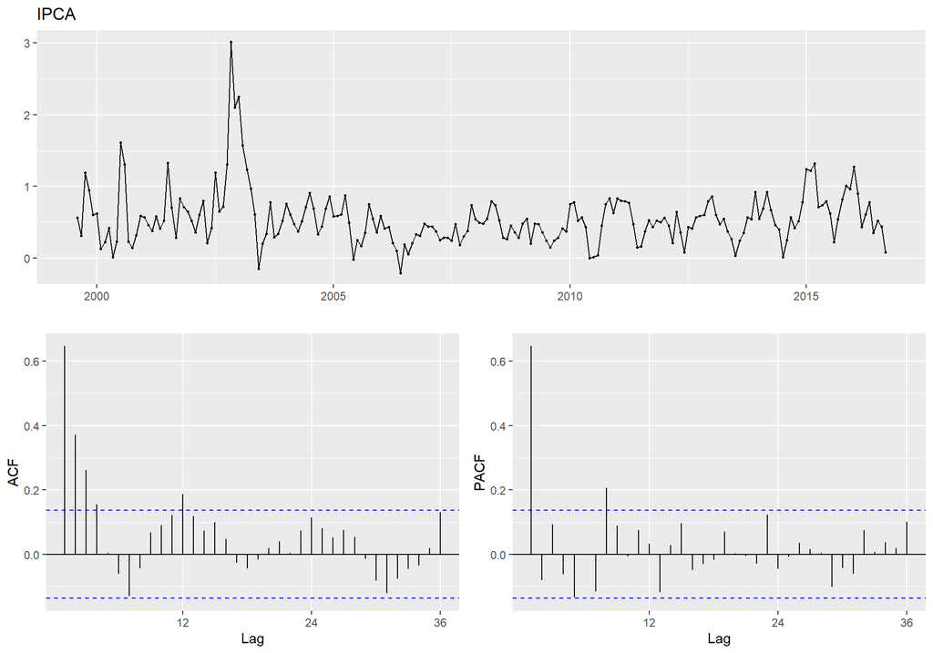

```r
# FAC e FACp
#Visualizando da série, da FAC e da FACp
ggtsdisplay(ipca, main='IPCA')
```

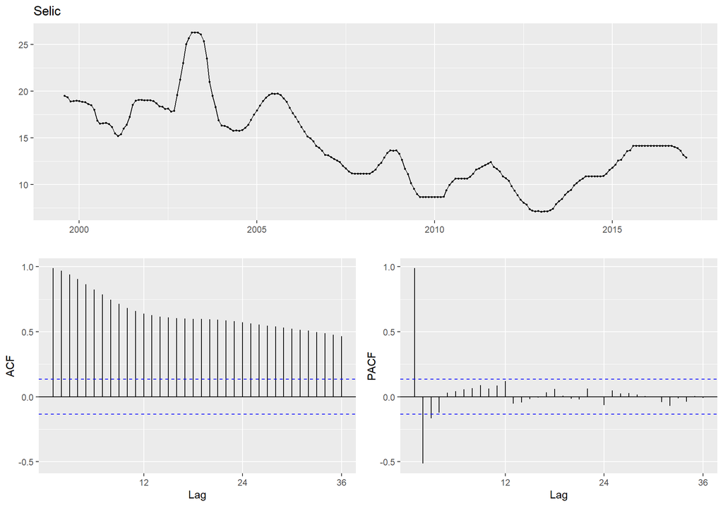

```r
ggtsdisplay(selic, main='Selic')
```

## 2.2 Teste de Raiz Unitária DF (Dickey-Fuller)

```r
#Estatistica de Teste DF para IPCA
ipcan.df <- ur.df(ipca, type = 'none', lags=0)
summary(ipcan.df)
```

```
#
# ###############################################
# # Augmented Dickey-Fuller Test Unit Root Test #
# ###############################################
#
# Test regression none
#
#
# Call:
# lm(formula = z.diff ~ z.lag.1 - 1)
#
# Residuals:
#     Min      1Q  Median      3Q     Max
# -0.9270 -0.1119  0.0592  0.2287  1.8630
#
# Coefficients:
#         Estimate Std. Error t value Pr(>|t|)
# z.lag.1 -0.11681    0.03259  -3.584 0.000423 ***
# ---
# Signif. codes:  0 '***' 0.001 '**' 0.01 '*' 0.05 '.' 0.1 ' ' 1
#
# Residual standard error: 0.3144 on 204 degrees of freedom
# Multiple R-squared:  0.05924, Adjusted R-squared:  0.05463
# F-statistic: 12.85 on 1 and 204 DF,  p-value: 0.000423
#
#
# Value of test-statistic is: -3.5842
#
# Critical values for test statistics:
#       1pct  5pct 10pct
# tau1 -2.58 -1.95 -1.62
```

```r
ipcad.df <- ur.df(ipca, type = 'drift', lags=0)
summary(ipcad.df)
```

```
#
# ###############################################
# # Augmented Dickey-Fuller Test Unit Root Test #
# ###############################################
#
# Test regression drift
#
#
# Call:
# lm(formula = z.diff ~ z.lag.1 + 1)
#
# Residuals:
#      Min       1Q   Median       3Q      Max
# -0.81377 -0.15679 -0.01559  0.11260  1.97623
#
# Coefficients:
#             Estimate Std. Error t value Pr(>|t|)
# (Intercept)  0.19027    0.03610   5.270 3.47e-07 ***
# z.lag.1     -0.34848    0.05358  -6.504 5.98e-10 ***
# ---
# Signif. codes:  0 '***' 0.001 '**' 0.01 '*' 0.05 '.' 0.1 ' ' 1
#
# Residual standard error: 0.2956 on 203 degrees of freedom
# Multiple R-squared:  0.1724,  Adjusted R-squared:  0.1684
# F-statistic:  42.3 on 1 and 203 DF,  p-value: 5.982e-10
#
#
# Value of test-statistic is: -6.5036 21.1547
#
# Critical values for test statistics:
#       1pct  5pct 10pct
# tau2 -3.46 -2.88 -2.57
# phi1  6.52  4.63  3.81
```

```r
ipcat.df <- ur.df(ipca, type = 'trend', lags=0)
summary(ipcat.df)
```

```
#
# ###############################################
# # Augmented Dickey-Fuller Test Unit Root Test #
# ###############################################
#
# Test regression trend
#
#
# Call:
# lm(formula = z.diff ~ z.lag.1 + 1 + tt)
#
# Residuals:
#      Min       1Q   Median       3Q      Max
# -0.83116 -0.15098 -0.01966  0.12367  1.96431
#
# Coefficients:
#               Estimate Std. Error t value Pr(>|t|)
# (Intercept)  0.2130762  0.0524126   4.065 6.87e-05 ***
# z.lag.1     -0.3505189  0.0537741  -6.518 5.56e-10 ***
# tt          -0.0002104  0.0003501  -0.601    0.548
# ---
# Signif. codes:  0 '***' 0.001 '**' 0.01 '*' 0.05 '.' 0.1 ' ' 1
#
# Residual standard error: 0.2961 on 202 degrees of freedom
# Multiple R-squared:  0.1739,  Adjusted R-squared:  0.1657
# F-statistic: 21.26 on 2 and 202 DF,  p-value: 4.168e-09
#
#
# Value of test-statistic is: -6.5184 14.1792 21.2624
#
# Critical values for test statistics:
#       1pct  5pct 10pct
# tau3 -3.99 -3.43 -3.13
# phi2  6.22  4.75  4.07
# phi3  8.43  6.49  5.47
```

São três diferentes fórmulas para o DF, baseados nas três possibilidade de testes: nenhum, com constante e com tendência. Estas fórmulas levam a três diferentes hipóteses a ser testadas. Em todos os três casos, contudo, se testa se $\delta=0$ (o coeficiente do valor de y defasadado é igual a zero), ou seja, se existe uma raiz unitária.

Assim, para `type="none"`, o output irá mostrar tau1, o valor crítico (com diferentes níveis de significância) para a hipótese nula de $\delta=0$.

Para `type="drift"`, tau2 é o valor crítico para o teste de $\delta=0$. phi1 se refere a segunda hipótese, que é a hipótese nula combinada de que a constante $a_0=\delta=0$, ou seja, ambos valores são testados para ser iguais a zero ao mesmo tempo.

Finalmente, para `type="trend"` as hipóteses testadas são $tau3:\delta=0$; $phi3:\delta=a_2=0$, com $a_2$ igual ao coeficiente da tendência e $phi2:a_0=\delta=a_2=0$.

## 2.3 Teste de Raiz Unitária ADF (Dickey-Fuller Aumentado)

```r
#Estatistica de Teste ADF para IPCA
ipcan.adf <- ur.df(ipca, type = 'none', selectlags='AIC')
summary(ipcan.adf)
```

```
#
# ###############################################
# # Augmented Dickey-Fuller Test Unit Root Test #
# ###############################################
#
# Test regression none
#
#
# Call:
# lm(formula = z.diff ~ z.lag.1 - 1 + z.diff.lag)
#
# Residuals:
#      Min       1Q   Median       3Q      Max
# -0.95070 -0.10148  0.05717  0.22037  1.88337
#
# Coefficients:
#            Estimate Std. Error t value Pr(>|t|)
# z.lag.1    -0.11004    0.03371  -3.264  0.00129 **
# z.diff.lag -0.04951    0.07034  -0.704  0.48231
# ---
# Signif. codes:  0 '***' 0.001 '**' 0.01 '*' 0.05 '.' 0.1 ' ' 1
#
# Residual standard error: 0.3153 on 202 degrees of freedom
# Multiple R-squared:  0.0604,  Adjusted R-squared:  0.05109
# F-statistic: 6.492 on 2 and 202 DF,  p-value: 0.001851
#
#
# Value of test-statistic is: -3.2644
#
# Critical values for test statistics:
#       1pct  5pct 10pct
# tau1 -2.58 -1.95 -1.62
```

```r
ipcad.adf <- ur.df(ipca, type = 'drift', selectlags='AIC')
summary(ipcad.adf)
```

```
#
# ###############################################
# # Augmented Dickey-Fuller Test Unit Root Test #
# ###############################################
#
# Test regression drift
#
#
# Call:
# lm(formula = z.diff ~ z.lag.1 + 1 + z.diff.lag)
#
# Residuals:
#     Min      1Q  Median      3Q     Max
# -0.7670 -0.1584 -0.0234  0.1325  1.9473
#
# Coefficients:
#             Estimate Std. Error t value Pr(>|t|)
# (Intercept)  0.20794    0.03862   5.384 2.02e-07 ***
# z.lag.1     -0.37818    0.05898  -6.412 1.00e-09 ***
# z.diff.lag   0.08497    0.07049   1.205    0.229
# ---
# Signif. codes:  0 '***' 0.001 '**' 0.01 '*' 0.05 '.' 0.1 ' ' 1
#
# Residual standard error: 0.2955 on 201 degrees of freedom
# Multiple R-squared:  0.1788,  Adjusted R-squared:  0.1706
# F-statistic: 21.88 on 2 and 201 DF,  p-value: 2.522e-09
#
#
# Value of test-statistic is: -6.4121 20.5591
#
# Critical values for test statistics:
#       1pct  5pct 10pct
# tau2 -3.46 -2.88 -2.57
# phi1  6.52  4.63  3.81
```

```r
ipcat.adf <- ur.df(ipca, type = 'trend', selectlags='AIC')
summary(ipcat.adf)
```

```
#
# ###############################################
# # Augmented Dickey-Fuller Test Unit Root Test #
# ###############################################
#
# Test regression trend
#
#
# Call:
# lm(formula = z.diff ~ z.lag.1 + 1 + tt + z.diff.lag)
#
# Residuals:
#      Min       1Q   Median       3Q      Max
# -0.78793 -0.14743 -0.02717  0.13496  1.93200
#
# Coefficients:
#               Estimate Std. Error t value Pr(>|t|)
# (Intercept)  0.2365636  0.0547321   4.322 2.43e-05 ***
# z.lag.1     -0.3811804  0.0591851  -6.440 8.68e-10 ***
# tt          -0.0002605  0.0003525  -0.739    0.461
# z.diff.lag   0.0863454  0.0705955   1.223    0.223
# ---
# Signif. codes:  0 '***' 0.001 '**' 0.01 '*' 0.05 '.' 0.1 ' ' 1
#
# Residual standard error: 0.2958 on 200 degrees of freedom
# Multiple R-squared:  0.181,   Adjusted R-squared:  0.1688
# F-statistic: 14.74 on 3 and 200 DF,  p-value: 1.044e-08
#
#
# Value of test-statistic is: -6.4405 13.8571 20.7841
#
# Critical values for test statistics:
#       1pct  5pct 10pct
# tau3 -3.99 -3.43 -3.13
# phi2  6.22  4.75  4.07
# phi3  8.43  6.49  5.47
```

## 2.4 Teste de Raiz Unitária Phillips-Perron e KPSS

```r
#Estatistica de Teste PP para IPCA
ipca.pp <- ur.pp(ipca, type = 'Z-tau', model="trend", lags='short')
summary(ipca.pp)
```

```
#
# ##################################
# # Phillips-Perron Unit Root Test #
# ##################################
#
# Test regression with intercept and trend
#
#
# Call:
# lm(formula = y ~ y.l1 + trend)
#
# Residuals:
#      Min       1Q   Median       3Q      Max
# -0.83116 -0.15098 -0.01966  0.12367  1.96431
#
# Coefficients:
#               Estimate Std. Error t value Pr(>|t|)
# (Intercept)  0.1915067  0.0362175   5.288  3.2e-07 ***
# y.l1         0.6494811  0.0537741  12.078  < 2e-16 ***
# trend       -0.0002104  0.0003501  -0.601    0.548
# ---
# Signif. codes:  0 '***' 0.001 '**' 0.01 '*' 0.05 '.' 0.1 ' ' 1
#
# Residual standard error: 0.2961 on 202 degrees of freedom
# Multiple R-squared:  0.4224,  Adjusted R-squared:  0.4167
# F-statistic: 73.87 on 2 and 202 DF,  p-value: < 2.2e-16
#
#
# Value of test-statistic, type: Z-tau  is: -6.596
#
#            aux. Z statistics
# Z-tau-mu              5.0404
# Z-tau-beta           -0.6023
#
# Critical values for Z statistics:
#                      1pct      5pct     10pct
# critical values -4.005675 -3.432727 -3.139875
```

```r
#Estatistica de Teste KPSS para IPCA
ipca.kpss <- ur.kpss(ipca, type = 'tau', lags='short')
summary(ipca.kpss)
```

```
#
# #######################
# # KPSS Unit Root Test #
# #######################
#
# Test is of type: tau with 4 lags.
#
# Value of test-statistic is: 0.1869
#
# Critical value for a significance level of:
#                 10pct  5pct 2.5pct  1pct
# critical values 0.119 0.146  0.176 0.216
```

# 3 Determinação da Estacionariedade

Um teste de segunda geração, mais poderoso e, por isto, aconselhado a ser usado, é o DF-GLS. O teste DF-GLS é uma versão modificada do teste ADF. A diferença é devido a uma alteração na série por meio de uma regressão por Mínimos Quadrados Generalizados (MQG) antes de executar o teste ADF.

Esse teste foi desenvolvido por Elliot et al. (1996), sugerindo uma mudança no ADF, em que retira-se as variáveis explicativas relativas a tendência determinística (constante e coeficientes de tendência), por meio de uma diferenciação na série. Existem duas possíveis hipóteses alternativas: a série é estacionária em torno de uma tendência linear ou é estacionária sem uma tendência linear.

Com relação a primeira alternativa, o teste DF-GLS é realizado inicialmente estimando o intercepto e a tendência via MQG, incluindo novas variáveis $\tilde{y}, x_t$ e $z_t$, em que

$$\tilde{y}=\left\{\begin{array}{rcc}
y_t &\mbox{se} & t=1 \\
y_t-ay_{t-1} & & t>1.
\end{array}\right.$$
$$x_t=\left\{\begin{array}{rcc}
1 &\mbox{se} & t=1 \\
1-a & & t>1.
\end{array}\right.$$

$$z_t=\left\{\begin{array}{rcc}
1 &\mbox{se} & t=1 \\
t-a(t-1) & & t>1.
\end{array}\right.$$

e $a=1-\frac{13,5}{T}$

Estima-se, então, uma regressão por MQO

$$\tilde{y}=\delta_0x_t+\delta_1z_t+\epsilon_t$$
os estimadores $\hat{\delta_0}$ e $\hat{\delta_1}$ são usados para se retirar a tendência dos dados, gerando uma nova série $y^*_t$. O passo seguinte é estimar um ADF na variável transformada

$$\Delta y^*_t=\alpha+\beta y^*_{t-1}+ \sum_{j=1}^{k}\xi_j\Delta
y^*_{t-j}+\epsilon_t$$
e verificar se $\beta=0$

No caso da segunda hipótese alternativa $a=1-\frac{7}{T}$, se elimina z da regressão (1) e estima (2) sobre a variável transformada, verificando se $\beta=0$. Os lags são escolhidos pelo critério de Schwarz $=[12(\frac{T}{100})^{1/4}]$ .

## 3.1 Estimação do DF-GLS no R

```r
#Verificaçao da Estacionariedade das séries
#Teste de raiz unitaria DF-GLS
#Definção do numero máximo de lags
print(12*(length(ipca)/100)^(1/4))
```

```
# [1] 14.37633
```

```r
print(12*(length(selic)/100)^(1/4))
```

```
# [1] 14.46278
```

```r
#Estatistica de Teste DFGLS para IPCA Com Constante

ipcaC.dfgls <- ur.ers(ipca, type = c("DF-GLS"),
                        model = c("constant"),
                        lag.max = 8)
summary(ipcaC.dfgls)
```

```
#
# ###############################################
# # Elliot, Rothenberg and Stock Unit Root Test #
# ###############################################
#
# Test of type DF-GLS
# detrending of series with intercept
#
#
# Call:
# lm(formula = dfgls.form, data = data.dfgls)
#
# Residuals:
#      Min       1Q   Median       3Q      Max
# -0.71172 -0.15503 -0.02669  0.13692  1.95798
#
# Coefficients:
#              Estimate Std. Error t value Pr(>|t|)
# yd.lag       -0.32117    0.09086  -3.535 0.000514 ***
# yd.diff.lag1  0.06432    0.09960   0.646 0.519225
# yd.diff.lag2 -0.11296    0.09082  -1.244 0.215130
# yd.diff.lag3  0.03533    0.08791   0.402 0.688248
# yd.diff.lag4  0.12207    0.08284   1.473 0.142294
# yd.diff.lag5 -0.10828    0.08158  -1.327 0.186023
# yd.diff.lag6  0.02972    0.07916   0.375 0.707732
# yd.diff.lag7 -0.23548    0.07232  -3.256 0.001340 **
# yd.diff.lag8 -0.08333    0.07189  -1.159 0.247887
# ---
# Signif. codes:  0 '***' 0.001 '**' 0.01 '*' 0.05 '.' 0.1 ' ' 1
#
# Residual standard error: 0.281 on 188 degrees of freedom
# Multiple R-squared:  0.2626,  Adjusted R-squared:  0.2273
# F-statistic:  7.44 on 9 and 188 DF,  p-value: 2.836e-09
#
#
# Value of test-statistic is: -3.5348
#
# Critical values of DF-GLS are:
#                  1pct  5pct 10pct
# critical values -2.58 -1.94 -1.62
```

```r
#Estatistica de Teste DFGLS para IPCA Com Tendência

ipcaT.dfgls <- ur.ers(ipca, type = c("DF-GLS"),
                     model = c("trend"),
                     lag.max = 8)
summary(ipcaT.dfgls)
```

```
#
# ###############################################
# # Elliot, Rothenberg and Stock Unit Root Test #
# ###############################################
#
# Test of type DF-GLS
# detrending of series with intercept and trend
#
#
# Call:
# lm(formula = dfgls.form, data = data.dfgls)
#
# Residuals:
#      Min       1Q   Median       3Q      Max
# -0.71955 -0.14625 -0.01585  0.14488  1.95440
#
# Coefficients:
#              Estimate Std. Error t value Pr(>|t|)
# yd.lag       -0.31374    0.08952  -3.505 0.000571 ***
# yd.diff.lag1  0.05892    0.09896   0.595 0.552302
# yd.diff.lag2 -0.11771    0.09027  -1.304 0.193858
# yd.diff.lag3  0.03129    0.08752   0.358 0.721090
# yd.diff.lag4  0.11912    0.08262   1.442 0.151018
# yd.diff.lag5 -0.11103    0.08139  -1.364 0.174180
# yd.diff.lag6  0.02766    0.07907   0.350 0.726889
# yd.diff.lag7 -0.23677    0.07230  -3.275 0.001258 **
# yd.diff.lag8 -0.08319    0.07198  -1.156 0.249229
# ---
# Signif. codes:  0 '***' 0.001 '**' 0.01 '*' 0.05 '.' 0.1 ' ' 1
#
# Residual standard error: 0.2811 on 188 degrees of freedom
# Multiple R-squared:  0.2618,  Adjusted R-squared:  0.2265
# F-statistic: 7.408 on 9 and 188 DF,  p-value: 3.114e-09
#
#
# Value of test-statistic is: -3.5047
#
# Critical values of DF-GLS are:
#                  1pct  5pct 10pct
# critical values -3.48 -2.89 -2.57
```

```r
#Estatistica de Teste DFGLS para Selic
selicC.dfgls <- ur.ers(selic, type = c("DF-GLS"),
                      model = c("constant"),
                      lag.max = 12)
summary(selicC.dfgls)
```

```
#
# ###############################################
# # Elliot, Rothenberg and Stock Unit Root Test #
# ###############################################
#
# Test of type DF-GLS
# detrending of series with intercept
#
#
# Call:
# lm(formula = dfgls.form, data = data.dfgls)
#
# Residuals:
#      Min       1Q   Median       3Q      Max
# -1.14502 -0.14590 -0.03042  0.11032  1.51682
#
# Coefficients:
#                 Estimate Std. Error t value Pr(>|t|)
# yd.lag        -0.0023263  0.0032970  -0.706  0.48135
# yd.diff.lag1   0.8970762  0.0719113  12.475  < 2e-16 ***
# yd.diff.lag2  -0.1206911  0.0935930  -1.290  0.19882
# yd.diff.lag3   0.1919255  0.0937367   2.047  0.04202 *
# yd.diff.lag4  -0.2834690  0.0944425  -3.001  0.00306 **
# yd.diff.lag5   0.1065778  0.0967161   1.102  0.27191
# yd.diff.lag6  -0.0008468  0.0969850  -0.009  0.99304
# yd.diff.lag7  -0.0295418  0.0968223  -0.305  0.76062
# yd.diff.lag8   0.0100314  0.0964414   0.104  0.91727
# yd.diff.lag9  -0.1445730  0.0941330  -1.536  0.12629
# yd.diff.lag10  0.1125734  0.0929579   1.211  0.22743
# yd.diff.lag11 -0.1700117  0.0915481  -1.857  0.06489 .
# yd.diff.lag12  0.1116574  0.0694704   1.607  0.10970
# ---
# Signif. codes:  0 '***' 0.001 '**' 0.01 '*' 0.05 '.' 0.1 ' ' 1
#
# Residual standard error: 0.2715 on 185 degrees of freedom
# Multiple R-squared:  0.7303,  Adjusted R-squared:  0.7114
# F-statistic: 38.54 on 13 and 185 DF,  p-value: < 2.2e-16
#
#
# Value of test-statistic is: -0.7056
#
# Critical values of DF-GLS are:
#                  1pct  5pct 10pct
# critical values -2.58 -1.94 -1.62
```

```r
selicT.dfgls <- ur.ers(selic, type = c("DF-GLS"),
                      model = c("trend"),
                      lag.max = 12)
summary(selicT.dfgls)
```

```
#
# ###############################################
# # Elliot, Rothenberg and Stock Unit Root Test #
# ###############################################
#
# Test of type DF-GLS
# detrending of series with intercept and trend
#
#
# Call:
# lm(formula = dfgls.form, data = data.dfgls)
#
# Residuals:
#      Min       1Q   Median       3Q      Max
# -1.06846 -0.12174 -0.01233  0.13401  1.54265
#
# Coefficients:
#                Estimate Std. Error t value Pr(>|t|)
# yd.lag        -0.015009   0.007500  -2.001   0.0468 *
# yd.diff.lag1   0.893395   0.071225  12.543   <2e-16 ***
# yd.diff.lag2  -0.109953   0.092929  -1.183   0.2383
# yd.diff.lag3   0.201284   0.093021   2.164   0.0318 *
# yd.diff.lag4  -0.272528   0.093760  -2.907   0.0041 **
# yd.diff.lag5   0.112187   0.095875   1.170   0.2434
# yd.diff.lag6   0.005842   0.096160   0.061   0.9516
# yd.diff.lag7  -0.023151   0.096001  -0.241   0.8097
# yd.diff.lag8   0.018132   0.095654   0.190   0.8499
# yd.diff.lag9  -0.142310   0.093279  -1.526   0.1288
# yd.diff.lag10  0.116730   0.092117   1.267   0.2067
# yd.diff.lag11 -0.166332   0.090736  -1.833   0.0684 .
# yd.diff.lag12  0.130030   0.069542   1.870   0.0631 .
# ---
# Signif. codes:  0 '***' 0.001 '**' 0.01 '*' 0.05 '.' 0.1 ' ' 1
#
# Residual standard error: 0.269 on 185 degrees of freedom
# Multiple R-squared:  0.7357,  Adjusted R-squared:  0.7171
# F-statistic: 39.61 on 13 and 185 DF,  p-value: < 2.2e-16
#
#
# Value of test-statistic is: -2.0013
#
# Critical values of DF-GLS are:
#                  1pct  5pct 10pct
# critical values -3.48 -2.89 -2.57
```

Para o IPCA com constante e 8 lags, em modulo o valor da estatistica de teste é maior do que o valor critico de 10%. Assim, pode-se rejeitar a hipotese nula de que a serie possui raiz unitária. O mesmo resultado é obtido quando se faz o teste com tendência.

No caso da SELIC, o valor da estatística de teste é menor do que o valor crítico, tanto com constante quanto com tendência. Assim, conclui-se que não pode rejeitar a hipótese nula de que a série possui raiz unitária, ou seja, a série não é estacionária.

# 4 Processo Tendência e Diferença Estacionário

A não estacionariedade de uma série tem relação com a presença de tendência na série, seja determinística ou estocástica. Se uma série tiver raiz unitária e sua diferenciação torná-la estacionária ela é dita processo estacionário em diferenças. Existem ainda as séries com tendência determinística, denominadas de série tendência estacionária pois flutuam em torno da tendência determinística. Para tornar a série estacionária, deve-se remover a tendência corretamente. Se for determinística, pegando os resíduos de uma regressão que estima a tendência. Se for estocástica, via diferenciação da série;